# MATH 3070 Lab Project 12

Kanishka Ragula

16 November, 2017

*Remember: I expect to see commentary either in the text, in the code with comments created using `#`, or (preferably) both! **Failing to do so may result in lost points!***

## Problem 1 (Verzani problem 8.7)

```r
library(Hmisc)
binconf(8, 10, alpha = 0.2)
```

```
##  PointEst    Lower     Upper
##       0.8 0.601596 0.9137628
```

```r
# 80% Confidence Interval of landing sticky side down
```

## Problem 2 (Verzani problem 8.10)

*A survey is taken of 250 students, and a $\hat{p}$ of 0.45 is found. The same survey is repeated with 1000 students, and the same $\hat{p}$ is found. Compare the two 95% confidence intervals. What is the relationship? Is the margin of error for the second one four times smaller? If not, how much smaller is it? (Use `binom.test()` to answer this problem.)*

```r
binconf(0.45 * 250, 250, alpha = 0.05)  #Calculate the intervals using binconf
```

```
##  PointEst     Lower     Upper
##      0.45 0.3895516 0.5119618
```

```r
binconf(0.45 * 1000, 1000, alpha = 0.05)
```

```
##  PointEst     Lower     Upper
##      0.45 0.4194154 0.4809673
```

```r
# The moe of the second one is only half as small because it is divided by
# the root of n so 4 becomes 2.
binom.test(112, 250)  #Using binom.test() as per the problem's requests
```

```
##
##  Exact binomial test
##
## data:  112 and 250
## number of successes = 112, number of trials = 250, p-value =
## 0.1137
## alternative hypothesis: true probability of success is not equal to 0.5
## 95 percent confidence interval:
##  0.3852992 0.5119484
## sample estimates:
## probability of success
##                  0.448
```

```r
binom.test(450, 1000)
```

```
##
##  Exact binomial test
##
## data:  450 and 1000
## number of successes = 450, number of trials = 1000, p-value =
## 0.001731
## alternative hypothesis: true probability of success is not equal to 0.5
## 95 percent confidence interval:
##  0.4188517 0.4814435
## sample estimates:
## probability of success
##                   0.45
```

## Problem 3 (Verzani problem 8.15)

*The `stud.recs` (**UsingR**) data set contains a sample of math SAT scores from some population in the variable `sat.m`. Find a 90% confidence interval for the mean math SAT score for this data. (Do not use `t.test(); find this confidence interval “by hand”.)*

```r
library(UsingR)
zstar = qnorm(0.05, lower.tail = FALSE)  #Calculate the z value for .05
sigma = sd(stud.recs$sat.m)  # Calculate the standard deviation
moe = zstar * sigma/sqrt(length(stud.recs$sat.m))  #By hand moe
meanMath = mean(stud.recs$sat.m)  # Calculate the mean
ci = c(Lower = meanMath - moe, Upper = meanMath + moe)  #Create a vector
ci  #Print it out
```

```
##   Lower   Upper
## 476.948 494.927
```

## Problem 4 (Verzani problem 8.15)

*For the `homedata` (**UsingR**) data set find 90% confidence intervals for both variables `y1970` and `y2000`, assuming the sample represents some population. Perform one sample t-test for each variable, use `t.test()`, but first discuss whether the model assumptions are appropriate (include some check of the assumptions, like a Q-Q plot).*

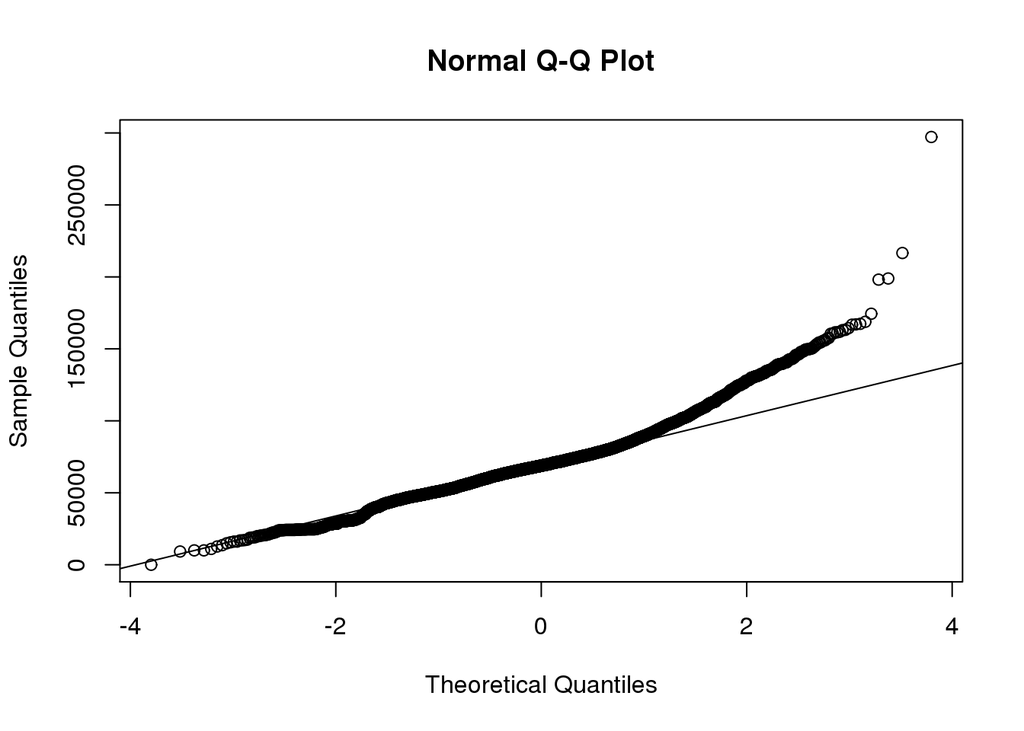

```r
qqnorm(homedata$y1970)  #QQ Plot for the 1970 data
qqline(homedata$y1970)
```

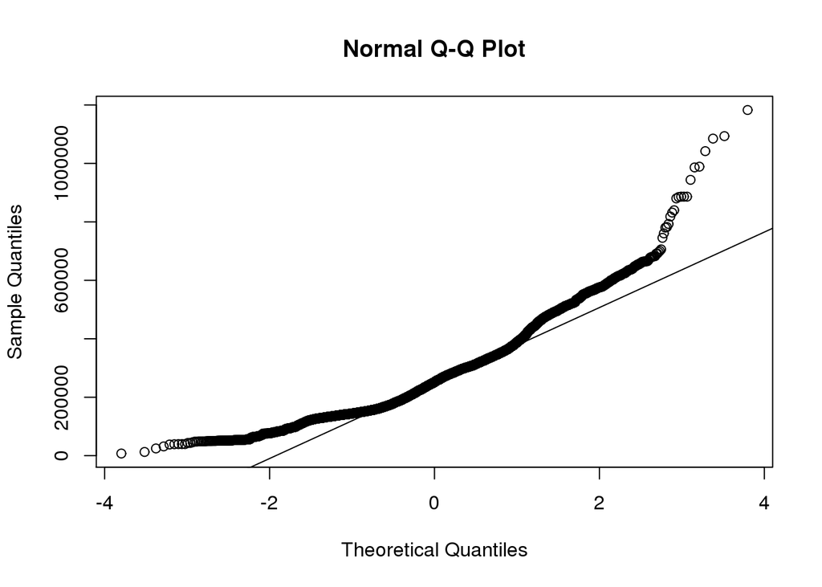

```r
qqnorm(homedata$y2000)  #QQ Plot for the 2000 data
qqline(homedata$y2000)
```

```r
# It would appear 1970 can have the model assumptions apply more easily than
# 2000 because the data seems more linear on the qq-plot, so more normal.
# However, the 1970 data is a bit more positively skewed than the normal and
# the 2000 data is more right skewed.  While neither is perfect, this should
# be fine.

t.test(homedata$y1970, conf.level = 0.9)
```

```
##
##  One Sample t-test
##
## data:  homedata$y1970
## t = 262.87, df = 6840, p-value < 2.2e-16
## alternative hypothesis: true mean is not equal to 0
## 90 percent confidence interval:
##  70377.72 71264.14
## sample estimates:
## mean of x
##  70820.93
```

```r
t.test(homedata$y2000, conf.level = 0.9)
```

```
##
##  One Sample t-test
##
## data:  homedata$y2000
## t = 169.79, df = 6840, p-value < 2.2e-16
## alternative hypothesis: true mean is not equal to 0
## 90 percent confidence interval:
##  265769.5 270970.0
## sample estimates:
## mean of x
##  268369.8
```